# How uneven was Bangalore’s rain this monsoon?

Codex

2026-10-01

## What are we trying to see?

The unit is a locality-day. Rain is the sum of WeatherUnion’s derived hourly `rain_mm`, but only on days with 24 valid hourly rain values. This is station rainfall, not an interpolated ward or city-wide surface.

## First, check coverage

```r
archive <- open_dataset(file.path(root_dir, "data", "weatherunion_bengaluru_hourly.parquet"))

hourly <- archive %>%
  filter(
    hour_ist >= as.POSIXct("2026-05-01 00:00:00", tz = "Asia/Kolkata"),
    hour_ist < as.POSIXct("2026-10-01 00:00:00", tz = "Asia/Kolkata")
  ) %>%
  select(locality_id, current_locality_name, hour_ist, rain_mm) %>%
  collect() %>%
  mutate(date = as.Date(hour_ist, tz = "Asia/Kolkata"))

stopifnot(!anyDuplicated(hourly[c("locality_id", "hour_ist")]))
stopifnot(all(hourly$rain_mm >= 0 | is.na(hourly$rain_mm)))

daily_raw <- hourly %>%
  group_by(locality_id, current_locality_name, date) %>%
  summarise(
    observed_hours = n(),
    valid_rain_hours = sum(!is.na(rain_mm)),
    rain_mm = sum(rain_mm, na.rm = TRUE),
    .groups = "drop"
  ) %>%
  mutate(
    # Missing hourly rain is not silently treated as a complete day's total.
    rain_mm = if_else(valid_rain_hours == 24, rain_mm, NA_real_)
  )

coverage <- daily_raw %>%
  summarise(
    days_in_window = n(),
    complete_days = sum(!is.na(rain_mm)),
    first_day = min(date),
    last_day = max(date),
    .by = c(locality_id, current_locality_name)
  ) %>%
  arrange(desc(complete_days), current_locality_name)

coverage
```

```
## # A tibble: 31 × 6
##    locality_id current_locality_name days_in_window complete_days first_day
##    <chr>       <chr>                          <int>         <int> <date>
##  1 ZWL005576   BIAL Airport Road                153           153 2026-05-01
##  2 ZWL003467   Banashankari                     153           153 2026-05-01
##  3 ZWL004924   Bannerghatta Road                153           153 2026-05-01
##  4 ZWL004164   Bellandur                        153           153 2026-05-01
##  5 ZWL008797   Devanahalli                      153           153 2026-05-01
##  6 ZWL006274   Electronic City                  153           153 2026-05-01
##  7 ZWL001196   HSR Layout                       153           153 2026-05-01
##  8 ZWL001273   Indiranagar                      153           153 2026-05-01
##  9 ZWL005530   JP Nagar                         153           153 2026-05-01
## 10 ZWL003159   Jalahalli                        153           153 2026-05-01
## # ℹ 21 more rows
## # ℹ 1 more variable: last_day <date>
```

There are 31 localities with at least some data in the requested window. To avoid letting short or late-starting sensors distort the comparison, I keep the 28 localities with at least 120 complete rain-days. Three localities are excluded from the main comparison because their coverage is too short or incomplete for a May–September seasonal total. The excluded localities are retained in the coverage table above rather than silently disappearing.

## The daily pattern: rain was episodic and spatially patchy

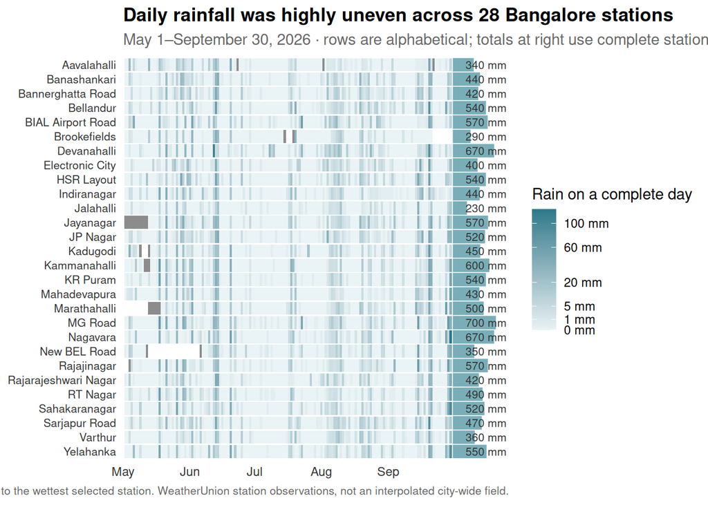

```r
selected <- coverage %>%
  filter(complete_days >= 120) %>%
  pull(current_locality_name)

row_totals <- daily_raw %>%
  filter(current_locality_name %in% selected) %>%
  group_by(current_locality_name) %>%
  summarise(seasonal_rain_mm = sum(rain_mm, na.rm = TRUE), .groups = "drop")

plot_daily <- daily_raw %>%
  filter(current_locality_name %in% selected) %>%
  left_join(row_totals, by = "current_locality_name") %>%
  mutate(
    # Alphabetical order makes the heatmap usable as a locality lookup table.
    current_locality_name = factor(
      current_locality_name,
      levels = rev(sort(unique(as.character(current_locality_name))))
    ),
    rain_for_tile = replace_na(rain_mm, 0),
    coverage = if_else(is.na(rain_mm), "Incomplete", "Complete")
  )

heat_path <- file.path(chart_dir, "bangalore-rain-variation-2026-daily-heatmap.png")
heat <- ggplot() +
  # Incomplete station-days get their own neutral tile, not an accidental zero.
  geom_tile(
    data = plot_daily %>% filter(coverage == "Incomplete"),
    aes(date, current_locality_name),
    fill = "#8C8C8C",
    width = 1,
    height = 0.9
  ) +
  geom_tile(
    data = plot_daily %>% filter(coverage == "Complete"),
    aes(date, current_locality_name, fill = rain_for_tile),
    width = 1,
    height = 0.9
  ) +
  geom_segment(
    data = distinct(plot_daily, current_locality_name, seasonal_rain_mm),
    aes(
      x = as.Date("2026-10-01"),
      xend = as.Date("2026-10-01") + 20 * seasonal_rain_mm / max(seasonal_rain_mm),
      y = current_locality_name,
      yend = current_locality_name
    ),
    linewidth = 4.5,
    lineend = "butt",
    colour = "#79AEB8"
  ) +
  geom_text(
    data = distinct(plot_daily, current_locality_name, seasonal_rain_mm),
    aes(
      x = as.Date("2026-10-26"),
      y = current_locality_name,
      label = number(seasonal_rain_mm, accuracy = 10, suffix = " mm")
    ),
    hjust = 1,
    size = 2.8,
    colour = "#333333"
  ) +
  annotate(
    "text",
    x = as.Date("2026-10-01"),
    y = Inf,
    label = "May–Sep total",
    hjust = 0,
    vjust = -0.7,
    size = 3.0,
    fontface = "bold",
    colour = "#333333"
  ) +
  scale_fill_gradient(
    low = "#EAF3F5",
    high = "#2B7A8B",
    trans = "sqrt",
    breaks = c(0, 1, 5, 20, 60, 100),
    labels = label_number(suffix = " mm"),
    name = "Rain on a complete day"
  ) +
  scale_x_date(
    breaks = seq(as.Date("2026-05-01"), as.Date("2026-09-01"), by = "month"),
    date_labels = "%b",
    limits = c(as.Date("2026-05-01"), as.Date("2026-10-27")),
    expand = expansion(mult = c(0, 0))
  ) +
  scale_y_discrete(limits = rev(sort(unique(as.character(plot_daily$current_locality_name))))) +
  labs(
    title = "Daily rainfall was highly uneven across 28 Bangalore stations",
    subtitle = "May 1–September 30, 2026 · rows are alphabetical; totals at right use complete station-days",
    x = NULL,
    y = NULL,
    caption = "Pale cells are complete dry days; dark cells are wetter days; grey cells are incomplete station-days. Right-hand bars share a linear scale, with the longest bar equal to the wettest selected station. WeatherUnion station observations, not an interpolated city-wide field."
  ) +
  theme_minimal(base_size = 11) +
  theme(
    panel.grid = element_blank(),
    axis.text.y = element_text(size = 8, colour = "#333333"),
    axis.text.x = element_text(colour = "#333333"),
    plot.title = element_text(face = "bold"),
    plot.subtitle = element_text(colour = "#666666"),
    plot.caption = element_text(colour = "#666666", size = 8),
    legend.position = "right"
  )
heat
```

```r
ggsave(heat_path, heat, width = 12, height = 9.5, dpi = 180, bg = "white")
```

The heatmap is the main chart because the daily values are mostly zero, with rainfall concentrated in a relatively small number of event days. It lets us see whether a wet day was broad-based or confined to a few parts of Bangalore without forcing the reader to trace dozens of overlapping lines.

The row-end totals make the heatmap self-contained: locality order supports lookup, while the totals provide the seasonal comparison without a second chart.

## What stands out?

```r
facts <- daily_raw %>%
  filter(current_locality_name %in% selected, !is.na(rain_mm)) %>%
  group_by(current_locality_name) %>%
  summarise(
    complete_days = n(),
    seasonal_rain_mm = sum(rain_mm),
    rainy_days = sum(rain_mm > 0),
    largest_day_mm = max(rain_mm),
    .groups = "drop"
  ) %>%
  arrange(desc(seasonal_rain_mm))

facts
```

```
## # A tibble: 28 × 5
##    current_locality_name complete_days seasonal_rain_mm rainy_days
##    <chr>                         <int>            <dbl>      <int>
##  1 MG Road                         153             702          75
##  2 Devanahalli                     153             673.         67
##  3 Nagavara                        153             672.         58
##  4 Kammanahalli                    150             595          50
##  5 Jayanagar                       141             574.         66
##  6 Rajajinagar                     149             570.         62
##  7 BIAL Airport Road               153             568.         65
##  8 Yelahanka                       153             550.         57
##  9 Bellandur                       153             540.         69
## 10 KR Puram                        153             540.         65
## # ℹ 18 more rows
## # ℹ 1 more variable: largest_day_mm <dbl>
```

```r
spread <- facts %>%
  summarise(
    wettest_total = max(seasonal_rain_mm),
    driest_total = min(seasonal_rain_mm),
    ratio = wettest_total / driest_total,
    gap_mm = wettest_total - driest_total,
    median_total = median(seasonal_rain_mm)
  )
spread
```

```
## # A tibble: 1 × 5
##   wettest_total driest_total ratio gap_mm median_total
##           <dbl>        <dbl> <dbl>  <dbl>        <dbl>
## 1           702         230.  3.05   472.         494.
```

In this snapshot, MG Road is the wettest of the selected stations at about 702 mm, while Jalahalli is the driest at about 230 mm. That is a spread of roughly 472 mm, or just over three times from the driest selected station to the wettest. This is enough to make “Bangalore rainfall” a misleading shorthand for this period: the archive is showing station-level spatial variation, not one uniform city experience.

## Verdict

Insightful: yes

The heatmap should be the single publishable chart: it carries event timing, spatial patchiness, and each station’s May–September total in one view. This remains an observational WeatherUnion comparison, not an estimate of rainfall across every neighbourhood or a causal explanation of why one area was wetter.

**Charts:**

- `docs/assets/analysis/bangalore-rain-variation-2026-daily-heatmap.png`

**Blog post:** not published. This is a draft analysis from the chat workflow; public cloud/site publishing requires explicit approval.